# LLM Aggregated Retrieval Consistency (Apple Pie Task)

*by James Bach*

### About LARC

Our ability to test and understand AI is critical to making responsible decisions about working with it. One of the tasks that we need AI to do is to pull data out of poorly structured contexts. Aggregated Retrieval Consistency is a way of evaluating LLMs on such tasks. The basic idea is described at https://www.satisfice.com/blog/archives/487957.

### About The Apple Pie Task

This is a report on the results of a LARC run that compares the behavior of four LLMs by a two stage process of first asking them to identify the ingredients of apple pie within a text that includes several recipes, then turning the question around and asking, for each identified ingredient, whether that is an ingredient of apple pie.

This is a fairly simple retrieval task, executed on a tiny corpus. A more realistic test of this concept might be performed on a few thousand pages of text from public domain cookbooks, would take a lot more computing time, and seems unlikely to produce more favorable results than this experiment does. I think this task is, if anything, a “happy path” case.

The full text of the recipes, including apple pie, is included in Appendix 1, below.

The correct list of ingredients is listed in Appendix 2, below. As I see it, there are 12-14 ingredients that could fairly be listed, depending on how you interpret the list.

The prompts I used are listed in Appendix 3, below.

The metrics depicted in this report include:

[output not shown]

Detailed data from each run can be found at https://www.satisfice.com/reports/ingredients.htm.

## Number of Ingredients Identified

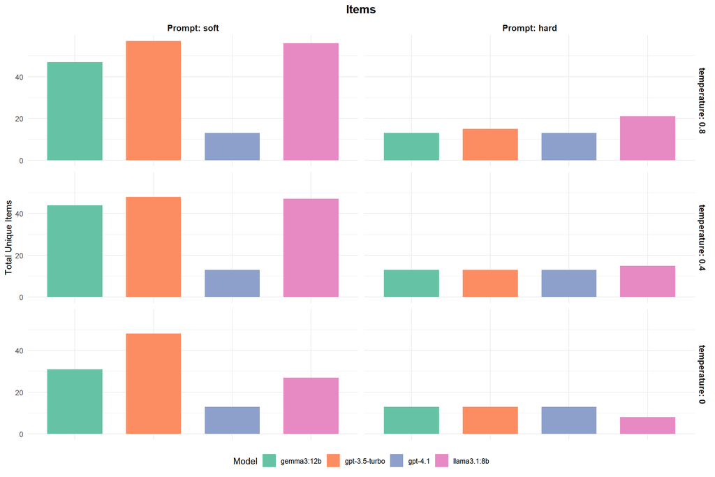

### Analysis

When asked for the ingredients to apple pie, most of the models give most of the ingredients to the other recipes unless they are specifically told (in the “hard prompt”) that they are to ignore everything except apple pie.

In my view, I shouldn’t have to provide this warning, and **GPT4.1** seems to corroborate that because it does handle the task correctly.

What I take away from this is that you don’t have to tell an LLM anything that is obvious in a prompt, *except for all the obvious things that you must tell it in detail*. The problem is we cannot predict in advance what those things are.

## Miss Rate

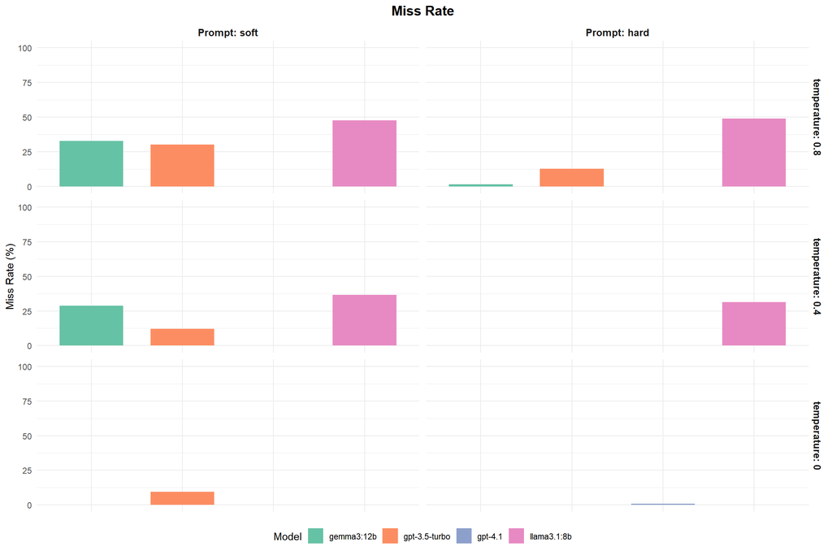

### Analysis

Notice that, for **Gemma** and **GPT3.5** the miss rate is dramatically lower when the harder prompt is used (remember that prompt is just two innocuous sentences longer than the soft prompt). This is because, with the softer prompt, the models were identifying a lot of non-apple pie ingredients– but not all of them all the time, as if they were not quite sure about those ingredients. When the hard prompt was use, those models consistently focused on the apple pie.

Thus at high temperature, **Llama** seems to have ignored the additional sentences of the hard prompt.

Although the effect is small, notice that **GPT4.1** actually got a little *less* consistent when given a hard prompt at temperature 0. This is surprising, but demonstrates that a policy of always providing longer, more detailed prompts does not always lead to better results.

## Repudiation

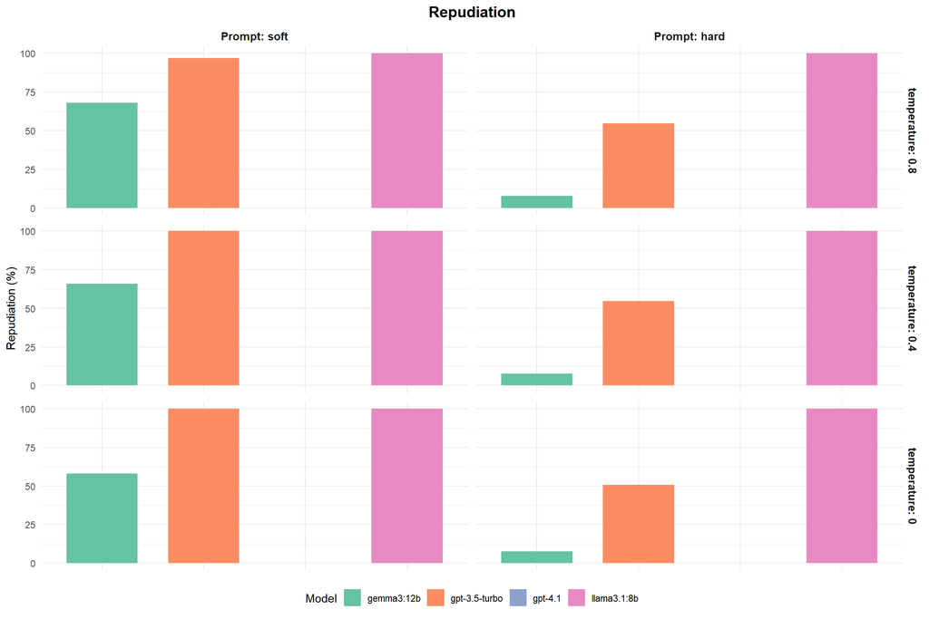

### Analysis

While **GPT4.1** was perfectly consistent, the other models struggled with repudiation.

Regardless of prompt type or temperature, **Llama** repudiated everything. Although it was not unsuccessful in surveying for apple pie ingredients, it could not be induced, in this experiment, to answer a direct question about the presence of any of those ingredients with the answer “true.” Clearly some very different process is happening when we ask it about a specific ingredient than when we ask it to list ingredients. Perhaps more experimentation with variations of the prompt will help.

Repudiation behavior with **GPT3.5** went from universal repudiation under the soft prompt to substantial affirmation under the hard prompt, varying term-by-term in an apparently random fashion.

**Gemma** repudiation nearly disappeared entirely when given the hard prompt. Puzzlingly, with the hard prompt, the only ingredient **Gemma** repudiated at any temperature was “egg.” Yet, egg was repudiated every single time (as if **Gemma** was channeling **Llama**, but just for eggs). This reminds us of the baffingly lumpy nature of LLM reliability, which can vary based on specific words in a text, for no apparent reason.

Before you formulate a theory on why **Gemma** doesn’t like eggs, you should know that with the *soft* prompt, egg got a perfect score with the **Gemma** model! It was identified 10 times and never repudiated. The problem child for the soft prompt was instead “granulated sugar.” (All other repudiations were for ingredients that weren’t apple pie ingredients, which is actually a good thing because they should have been repudiated.)

Good luck with your theorizing… I’m stumped.

## Ambivalence

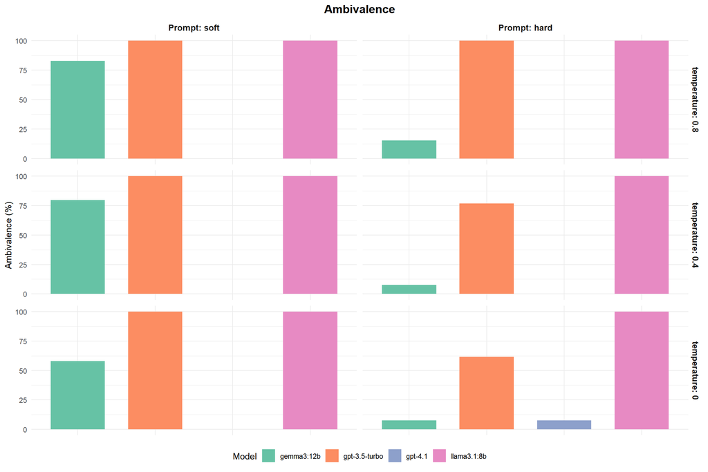

### Analysis

Clearly, the **Gemma** model benefited the most from the harder prompt, while **GPT4.1**, otherwise excellent, was a little thrown off by it.

## Summary Statistics

| model_family | Prompt | temperature | items | miss_rate | repudiation | ambivalence |
| --- | --- | --- | --- | --- | --- | --- |
| gemma3:12b | soft | 0.8 | 47 | 32.7659575 | 68.085106 | 82.978723 |
| gemma3:12b | soft | 0.4 | 44 | 28.8636364 | 65.909091 | 79.545455 |
| gemma3:12b | soft | 0 | 31 | 0.0000000 | 58.064516 | 58.064516 |
| gemma3:12b | hard | 0.8 | 13 | 1.5384615 | 7.692308 | 15.384615 |
| gemma3:12b | hard | 0.4 | 13 | 0.0000000 | 7.692308 | 7.692308 |
| gemma3:12b | hard | 0 | 13 | 0.0000000 | 7.692308 | 7.692308 |
| gpt-3.5-turbo | soft | 0.8 | 57 | 30.1754386 | 97.017544 | 100.000000 |
| gpt-3.5-turbo | soft | 0.4 | 48 | 12.0833333 | 100.000000 | 100.000000 |
| gpt-3.5-turbo | soft | 0 | 48 | 9.3750000 | 100.000000 | 100.000000 |
| gpt-3.5-turbo | hard | 0.8 | 15 | 12.6666667 | 54.666667 | 100.000000 |

[output cut: 14 more lines]

## Discussion

What this little experiment demonstrates is that there can be no simple answer to the question “can an LLM do X reliably?” without conducting extensive testing.

The testing demonstrated here, although extensive in some sense (many hours of computation and a total of 6310 prompts offered) merely scratches the surface. It merely tells us that more prompting strategies and temperature variations are in order. Or perhaps pre-processing the text of the recipes would help.

In any real-life application of AI, there are many knobs we can turn and levers to pull. What this data shows is that we will probably not be able to take refuge in general heuristics such as “always write a long and detailed prompt” or “never use the Llama model.” Whatever we do we will have to test it probabilistically– doing many repetitions and repeating with tiny variations. This will be expensive, but there may be no alternative if we want to release a reliable product.

I intend to perform this task with other domains, such as identifying side effects in pharmaceutical documentation, or names of people in news stories.

## Appendix 1: Recipe Text

[output not shown]

[output cut: 120 more lines]

```
In the same pan, melt butter and add mushrooms, garlic, and thyme. Cook until the mixture is dry and browned, about 10 minutes. Set aside to cool.

On a sheet of plastic wrap, lay out the prosciutto slices, slightly overlapping to form a rectangle. Spread the mushroom mixture evenly over the prosciutto.

Place the seared beef on top of the mushroom layer, then use the plastic wrap to roll the prosciutto tightly around the beef. Chill for about 20 minutes to firm up.

Roll out the puff pastry on a floured surface large enough to completely wrap the beef. Remove the plastic wrap and place the beef in the center of the pastry. Brush the edges with beaten egg and wrap the pastry around the beef, sealing the edges. Trim any excess pastry.

Place the wrapped beef seam-side down on a parchment-lined baking sheet. Brush the top with the remaining egg wash.

Bake for 40 to 45 minutes, or until the pastry is golden brown and an instant-read thermometer inserted into the center of the beef reads 125°F (52°C) for medium rare.

Let rest for 10 minutes before slicing.

Serve with red wine sauce or gravy if desired.
```

## Appendix 2: Expected Ingredients

A basic reading affords this interpretation of the ingredients of apple pie yield 13 in total:

- all-purpose flour
- salt
- unsalted butter
- ice water
- medium apples (Granny Smith, Honeycrisp, or a mix)
- granulated sugar
- brown sugar
- ground cinnamon
- ground nutmeg
- lemon juice
- butter
- egg
- coarse sugar

However, some variations are also reasonable. For instance, butter may be left out, since the reference to it may have been intended to refer to unsalted butter, and unsalted butter could be used in that scenario. Also, Honeycrisp and Granny Smith apples may be called out separately. Thus the correct number of ingredients may be as little as 12 or as many as 14, as I reckon it.

Although consistency, rather than correctness, is what LARC tries to measure, it’s important to understand that certain kinds of inconsistency may be endemic to the nature of the retrieval task, given that there is more than one reasonable way of making sense of the data.

## Appendix 3: Prompts

The basic, or “soft” survey prompt that I used was:

```
List every unique ingredient mentioned in the apple pie recipe that is below the line of dashes. List only the ingredient names, not the amounts. Answer in the form of a JSON array of strings with no other commentary. Use the key 'results' for the array:

--------------------------------
```

The corresponding presence prompt was:

```
Is "{item}" an ingredient listed in the apple pie recipe that is below the line of dashes. Answer in the form of a JSON object with one key: 'exists', which should be true or false:

--------------------------------
```

Obviously, the software replaced {item} with the corresponding ingredient for each round of prompting.

To “harden” these prompts I added these two sentences to the start of each prompt:

```
Below the line of dashes is a text that comprises a set of recipes. Ignore all recipes except the one I am asking you about.
```

Note that these sentences contribute no important information. Everything a human or LLM should need to perform the task correctly is already in the soft versions of the prompt. However, I did note a substantial improvement in LLM performance when using the hard prompt, except in one odd case where the otherwise perfect ChatGPT 4.1 model got a little *worse*.